# Introduction to Thermodynamics

Dr. Ahmad Redaa

2025-07-08

# Systems

## What Is a System?

A **system** is the part of the universe under study, such as a magma chamber or metamorphic rock.

## Surroundings

The **surroundings** include everything outside the system that can exchange energy or matter with it.

## Energy

Energy is the capacity to do **work** or cause **change**. All natural processes involve energy transfer.

# Types of Systems

| System Type | Matter Exchange | Energy Exchange | Example |
| --- | --- | --- | --- |
| Open | Yes | Yes | Volcano releasing lava and gas |
| Closed | No | Yes | Sealed magma chamber |
| Isolated | No | No | Ideal thermos (hypothetical) |

# Types of Energy in Systems

- **Thermal energy**: due to temperature
- **Chemical energy**: stored in bonds
- **Potential energy**: related to position
- **Kinetic energy**: motion (minor in rocks)
- **Radiative energy**: from radioactive decay

# Stability and Energy

- Stable = lowest energy state (a rock sitting on the ground).
- Unstable = wants to change right away (a rock in mid-air).
- Metastable = seems stable, but could change if disturbed (like diamonds, which should turn into graphite—but don’t, because of energy barriers).

## Natural systems tend to move toward the lowest energy state.

# Gibbs Free Energy (G)

It tells us whether a mineral or rock will be stable under certain conditions.

The equation is:

$$G = H - T \times S$$

- $H$: Enthalpy (heat content)
- $S$: Entropy (disorder)
- $T$: Temperature (K)
- $\Delta G < 0$: spontaneous
- $\Delta G = 0$: equilibrium

## Enthalpy (H)

Total **heat content** of the system. Reactions with ΔH < 0 release heat.

## Entropy (S)

Degree of **disorder**.  
Solids = low S, gases = high S.

# Energy Levels

- **High energy**: system is reactive, unstable
- **Low energy**: system is more stable

# Stability of Systems

| Stability Type | Description | Example |
| --- | --- | --- |
| Stable | Lowest Gibbs free energy (G), unchanging | Quartz at Earth’s surface |
| Metastable | Appears stable, not lowest energy, may transform | Diamond at surface conditions |
| Unstable | Quickly changes to reach lower energy | Hot lava cooling to rock |

# Stable State

A system is in a stable state when it is at the lowest possible energy under the given conditions. It won’t change on its own unless something external acts on it.

## Characteristics:

- Minimum energy
- Spontaneous changes do not happen
- Hard to disturb

## Everyday Examples:

- A rock resting on the ground: It’s at its lowest potential energy. It won’t move unless you push it.
- Rust (iron oxide): Iron exposed to air and moisture eventually rusts. Once rust forms, it’s a stable compound and won’t change back to iron spontaneously.
- Ice at -10°C: It’s stable in solid form below freezing.

# Metastable State

- A metastable state is not the lowest energy state, but the system is “stuck” there because it needs a push (energy input) to move to a more stable state. It can persist for a long time, sometimes indefinitely.

## Characteristics:

- Not the lowest energy, but “trapped”
- Needs a kick to change
- Appears stable at first glance

## Everyday Examples:

- Diamond: It’s actually metastable at Earth’s surface. Graphite is the stable form of carbon at low pressure—but diamonds don’t turn into graphite unless you add a lot of heat or time.
- Supersaturated solution: Like honey that hasn’t crystallized yet—just shake or cool it, and sugar crystals suddenly form.
- Stretching a rubber band: It stays stretched (metastable) but snaps back (stable) if you let go.
- Cooled magma forming glass (like obsidian): It’s metastable because it avoids forming an ordered crystal structure.

# Unstable State

- An unstable state means the system is at high energy, and it wants to change immediately. It will do so spontaneously without needing help.

## Characteristics:

- High energy
- Changes rapidly
- Not sustainable

## Everyday Examples:

- A rock rolling down a hill: It’s unstable at the top—gravity makes it move to a lower energy state (the bottom).
- A stretched spring let go: It snaps back instantly.
- Combustible gas near a spark: A match near gasoline vapor causes a fast and spontaneous change—explosion.
- Hot coffee on a cold day: It cools down quickly because it’s not in thermal equilibrium with the surroundings.

# Why Study Thermodynamics in Geology?

- Thermodynamics helps us predict what minerals form in a rock at certain temperatures and pressures. It’s like the “rules of the game” for understanding when rocks melt, crystallize, or transform into new minerals.
- We ask questions like:
  - “Will this mineral be stable at 700°C and 5 kilobars?”
  - “What happens if we add water to magma?”
  - “Why do certain minerals form first as magma cools?”

# Thermodynamics in Petrology

Helps us understand:  
- Mineral stability  
- Crystallization and melting  
- Metamorphic reactions

# Reactants and Products

Petrologic processes can be written as:

$$\text{A} + \text{B} + \dots \rightarrow \text{Q} + \text{R} + \dots$$

- **Reactants**: substances consumed
- **Products**: substances formed

## Examples:

- Polymorphic: Kyanite → Sillimanite
- Metamorphic:
  $$\text{Muscovite} + \text{Quartz} \rightarrow \text{K-feldspar} +
  \text{Al}_2\text{SiO}_5 + \text{H}_2\text{O}$$
- Crystallization:
  $$\text{Magma} \rightarrow \text{Olivine} + \text{Pyroxene}$$

# Reference State

Standard conditions for tabulated data:  
- Temperature: 298.15 K  
- Pressure: 1 bar  
- Pure phases in stable form

# Extensive Variables of State

## Depend on system size:

- Mass
- Volume
- Total energy

## Intensive variables include

- T
- P
- composition (x)

# Gibbs Free Energy of Reaction

$$\Delta G_{\text{rxn}} = \sum G_{\text{products}} - \sum
G_{\text{reactants}}$$

- ΔG < 0 → forward reaction
- ΔG = 0 → equilibrium
- ΔG > 0 → reaction is not spontaneous

# Phase Diagrams

- Show stable phases under different pressure-temperature (P–T) conditions.
- Example: Al₂SiO₅ polymorph diagram (kyanite, sillimanite, andalusite).

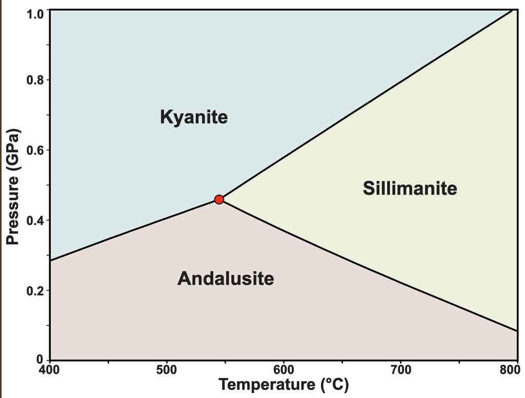

Source: [http://www.science.smith.edu/](http://www.science.smith.edu/~jbrady/petrology/metrocks-diagrams/Al2SiO5.php)

# Equilibrium Curves

Lines on a phase diagram where two phases coexist.  
Defined by:

## Clapeyron Equation

$$\frac{dP}{dT} = \frac{\Delta S}{\Delta V}$$

Where: - ΔS = entropy change - ΔV = volume change

Predicts the slope of equilibrium lines in P–T space.

## Le Châtelier’s Principle

> “If a system at equilibrium is disturbed, it shifts to reduce that disturbance.”

### Application:

- ↑ Pressure → favors denser phase
- ↑ Temperature → favors endothermic direction

# Metamorphic Rocks: Phase Diagrams

http://www.science.smith.edu/~jbrady/petrology/metrocks-diagrams/metDiagrams.php